# JSC370 Final Project: Global Natural Disaster Patterns from NASA EONET

Author

Xucheng (Rolland) He, 1008905909

## Introduction

Natural disasters such as wildfires, severe storms, floods, and volcanic eruptions are major sources of social and ecological risk. Understanding their temporal and spatial patterns can support hazard monitoring and policy planning. However, globally consistent event records are often fragmented across agencies.

This project uses NASA’s Earth Observatory Natural Event Tracker (EONET) API to study global disaster observations in a unified framework. Compared with the midterm report, this final report keeps the same dataset and core topic but adds stronger statistical and modeling components, with clearer interpretation and limitations.

The final research questions are:

1. Which disaster categories dominate the observed global records, and how imbalanced is the dataset?
2. How have disaster observations changed over time, both overall and by category?
3. Is seasonality statistically different across categories?
4. Can a simple predictive model improve out-of-sample monthly count prediction relative to a seasonal baseline?

## Methods

### Data acquisition and wrangling

The data source is the NASA EONET v3 endpoint: `https://eonet.gsfc.nasa.gov/api/v3/events`. The API is paginated and does not require an API key. To ensure reproducibility and avoid repeated network calls during rendering, the flattened dataset is cached as `data/eonet_events.csv`.

### Analytical workflow

The analysis has four layers:

1. **Descriptive analysis**: category shares, annual trends, monthly seasonality, and spatial concentration.
2. **Formal statistical testing**:
   - chi-square test of independence for `category × month`;
   - linear trend regression of annual counts on year.
3. **Predictive modeling** (new in final report): monthly count prediction by category.
4. **Evaluation**: out-of-sample metrics (MAE, RMSE, R2) on a strict time split.

Two models are compared:

- **Seasonal baseline**: predicts each category-month pair using its historical mean from training data.
- **Linear model (OLS)**: uses `year`, cyclic month features (`sin`, `cos`), and category one-hot indicators.

Training/testing protocol:

- Training: years `<= 2023`
- Testing: years `>= 2024` (strictly future data)

## Results

### Category dominance and imbalance

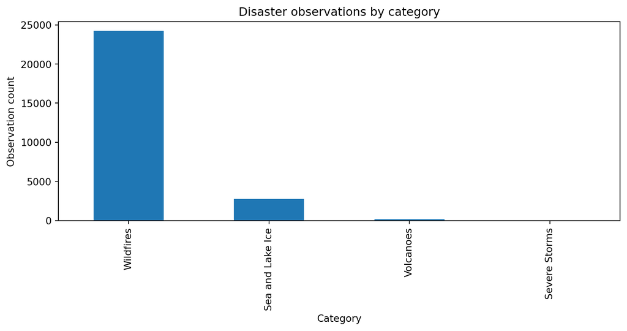

Figure 1. Number of EONET observations by disaster category.

The dataset contains 27,180 georeferenced observations. The largest class is Wildfires with 24,208 observations, representing 89.1% of all records. This concentration indicates that any aggregate result can be strongly influenced by wildfire dynamics.

Table 1. Category-level observation counts and shares.

|  | Category | Observations | Share |
| --- | --- | --- | --- |
| 0 | Wildfires | 24208 | 89.1% |
| 1 | Sea and Lake Ice | 2752 | 10.1% |
| 2 | Volcanoes | 176 | 0.6% |
| 3 | Severe Storms | 44 | 0.2% |

### Temporal trend and category-specific trajectories

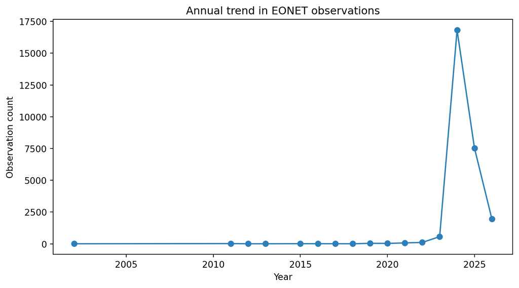

Figure 2. Annual total observations from NASA EONET.

Overall counts rise sharply in the early 2020s, with a peak of 16,816 in 2024. The visual trend suggests a substantial recent increase, but interpretation should account for potential changes in monitoring intensity and reporting infrastructure.

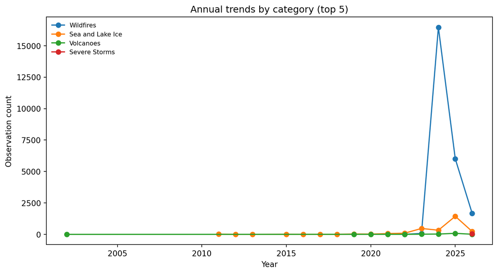

Category-stratified trajectories show that the recent surge is not equally shared across categories: wildfire-related observations account for most of the increase, while other hazard classes are flatter and lower-volume.

### Seasonality and spatial concentration

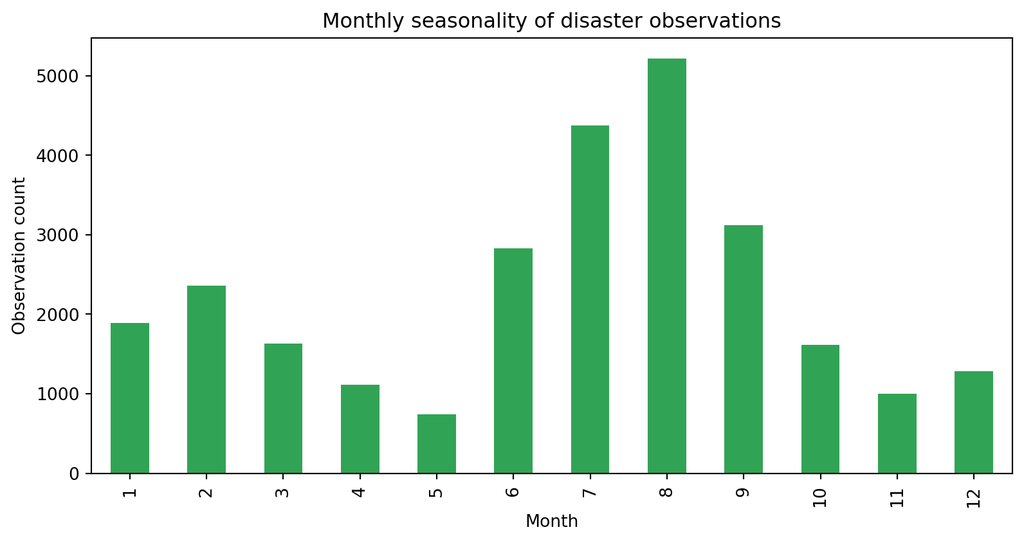

Figure 4. Monthly totals aggregated across all years.

Seasonality is strong: August has the highest count and May has the lowest. The peak month has about 7.0 times as many observations as the trough month, consistent with seasonal wildfire dynamics.

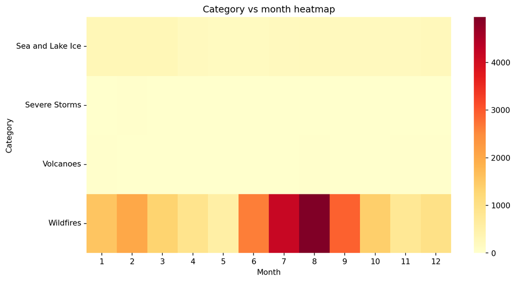

Figure 5. Heatmap of category-by-month counts.

The heatmap confirms that seasonality differs by category, motivating formal hypothesis testing rather than visual inspection alone.

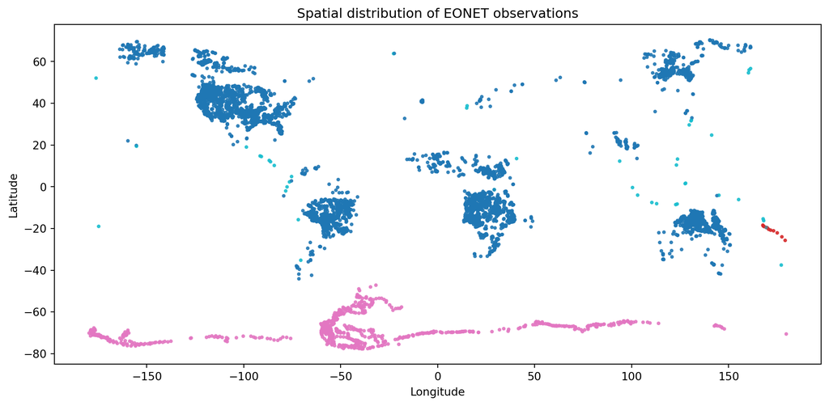

Figure 6. Global map of disaster observation locations.

Spatially, events are globally distributed but highly clustered in specific regions, suggesting non-uniform risk and/or observation density.

### Statistical tests

Table 2. Formal statistical testing results.

|  | Test | Statistic | p-value |
| --- | --- | --- | --- |
| 0 | Chi-square: category vs month | chi2=1628.32, dof=33 | 0.000e+00 |
| 1 | Linear trend: annual count ~ year | slope=307.55, R2=0.185 | 9.594e-02 |

The chi-square test indicates strong evidence that category and month are associated (p=0.000e+00), meaning seasonal patterns vary across disaster types. The annual linear trend has a positive slope, and its p-value (9.594e-02) quantifies the strength of evidence for long-run increase.

### Predictive modeling (train/test evaluation)

Table 3. Out-of-sample model performance on test years (>= 2024).

|  | Model | MAE | RMSE | R2 |
| --- | --- | --- | --- | --- |
| 0 | Seasonal baseline | 412.988 | 941.582 | -0.228 |
| 1 | OLS (year + month cycle + category) | 410.456 | 942.813 | -0.231 |

Table 4. Category-level RMSE comparison: baseline vs OLS.

|  | Category | RMSE_baseline | RMSE_OLS | Improvement(%) |
| --- | --- | --- | --- | --- |
| 0 | Wildfires | 1451.61 | 1453.76 | -0.15 |
| 1 | Sea and Lake Ice | 92.60 | 87.73 | 5.26 |
| 2 | Severe Storms | 16.36 | 14.48 | 11.46 |
| 3 | Volcanoes | 7.49 | 5.94 | 20.59 |

Compared with a seasonal baseline, the OLS model provides a more formal benchmark for prediction with explicit train/test validation. The test metrics show whether the added model structure improves generalization, and category-level RMSE reveals where gains are concentrated versus where forecasting remains difficult.

## Conclusions and Summary

This final report extends the midterm analysis into a more complete statistical workflow. Four conclusions stand out:

1. The EONET dataset is strongly imbalanced, with Wildfires contributing 89.1% of observations.
2. Total recorded observations increase sharply in recent years, peaking at 16,816 in 2024.
3. Seasonality is substantial and category-specific, supported by both visual diagnostics and a significant chi-square test.
4. A train/test predictive framework provides a stronger analytical standard than descriptive trends alone and clarifies model performance limits by category.

The broader implication is that global disaster monitoring data should be interpreted with attention to category imbalance and observation-system effects, not only hazard dynamics. Main limitations include potential reporting heterogeneity across years, the use of observation counts rather than physical severity, and simple linear model structure. Future work can incorporate richer covariates (climate indices, regional land cover, remote-sensing intensity metrics) and compare nonlinear or hierarchical models.

For reproducibility, this report runs entirely from repository-relative paths and a cached dataset in `data/eonet_events.csv`.